# Storm Petrel Foraging Radius Model

This foraging radius model is based on this paper: “How to Live in Colonies: Foraging Range and Patterns of Density around a Colony of Black-Headed Gulls Larus ridibundus in Relation to the Gulls’ Energy Budget”

The authors create a model that gives the estimated foraging range for gulls but we can use it for Storm Petrels to explore how they manage to range so far out.

The model is:

$$\huge{R=\frac{V.q_f.L}{2.E}}$$

where $E=(1-q_f)E_r+q_fE_f+E_j$

The components that make up the model are $R$ which is the radius; $V$ which is the velocity of the bird in metres per second; $qf$ which is the proportion of time flying; $L$ which is the energetic load the bird can carry in Joules; $E_f$ which is the energetic cost of flight in Watts; $E_r$ which is the cost of other activities e.g. roosting and is also in Watts and finally $E_j$ which is the energy expenditure of the nestlings in watts.

There isn’t a lot of data on the energetics for European Storm Petrels but we do have information on Leach’s and Wilson’s which can be used as proxies.

We know that the cost of being away from the nest for Wilson’s is 1.82 Watts and the cost of being on the nest is 0.94 Watts. We can choose the lower end of the range for these values because European Storm Petrels are smaller than Wilson’s giving 1.04 Watts and 0.68 Watts for birds away from and on the nest respectively. The rate of energy delivered to the chick is 0.95 Watts.

A European Storm Petrel has a capacity to hold ~ 5 grams of food which has an energy density of 4330 Joules per gram. Also relevant is the gut passage time of Wilson’s storm-petrel, which is ~ 12 hours.

We can build up the model using these components.

```r
Er <- 0.68#  Watts - energetic cost of other activites
V <- 4.9 #  metres per second - flight speed
Ej <- 0.95 # Watts - energy expenditure of juveniles
qf <- 0.95# 0.05 # proprtion of time flying
L <-  21650 #  load size in joules * energy density of food
Ef <- 1.04 # watts - energy expenditure during flight
petrelRadius <- function(qf,Er,Ef,Ej,V,L){
  R = (V * L * qf) / (2 * ((1-qf)*Er + (qf*Ef) + Ej))
  return(R/1000) # return in km
}
petrelRadius(qf,Er,Ef,Ej,V,L)
```

```
[1] 25.55293
```

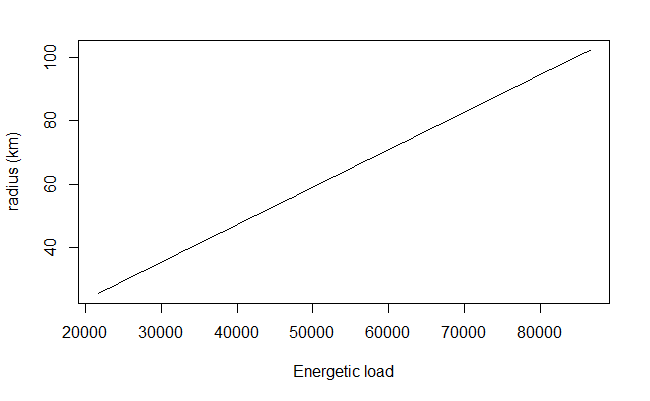

```r
petrelRadius <- function(L){
  R = (4.9 * L * 0.95) / (2 * ((1-0.95)*0.68 + (0.95*1.04) + 0.95))
  return(R/1000) # return in km
}
curve(petrelRadius, from=21650, to=86600, xlab="Energetic load", ylab="radius (km)")
```

Here we can remove the cost of the chick by setting $E_j$ = 0 and again increase the number of meals the adult can gain.

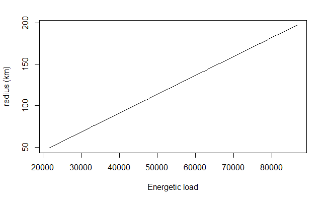

```r
petrelRadius <- function(L){
  R = (4.9 * L * 0.95) / (2 * ((1-0.95)*0.68 + (0.95*1.04) + 0))
  return(R/1000) # return in km
}
curve(petrelRadius, from=21650, to=86600, xlab="Energetic load", ylab="radius (km)")
```

Other changes seem to have a much smaller effect on foraing range so the birds must be eating multiple times to get out to some distant feeding ground. E.g. here is the case where we vary flight speed from the average (4.9 m/s) to the max (11.2 m/s) while restricting the bird to one load of food.

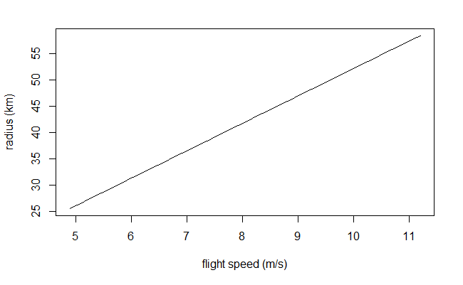

```r
petrelRadius <- function(V){
  R = (V * 21650 * 0.95) / (2 * ((1-0.95)*0.68 + (0.95*1.04) + 0.95))
  return(R/1000) # return in km
}
curve(petrelRadius, from=4.9, to=11.2, xlab="flight speed (m/s)", ylab="radius (km)")
```